# Barcode processing

Max Trauernicht

2020-07-15

# knitr document van Steensel lab

# TF reporter barcode processing

# Introduction

18,000 TF reporters on pMT02 were transfected into mESCs and NPCs (in total 7 different conditions), sequencing data yielded barcode counts of these experiments. These counts will be processed in this script.

## Description of Data

[output not shown]

# Data processing

## Path, Libraries, Parameters and Useful Functions

```r
knitr::opts_chunk$set(echo = TRUE)
StartTime <-Sys.time()

# 8-digit Date tag:
Date <- substr(gsub("-","",Sys.time()),1,8)
# libraries:
library(data.table)
library(plyr)
library(stringr)
library(ggpubr)
library(GGally)
library(vwr)
library(dplyr)
```

```r
library(tibble)
library(plotly)
library(ggbeeswarm)
library(haven)
library(readr)
library(parallel)
library(RColorBrewer)
library(gridExtra)
```

### Custom functions

Functions used thoughout this script.

```r
SetFileName <- function(filename, initials) {
  # Set filename with extension and initials to make filename with date integrated.
  filename <- substitute(filename)
  initials <- substitute(initials)
  filename <- paste0(initials, Date, filename)
  filename
}


# From Fede:
# ggpairs custom functions
corColor <- function(data, mapping, color = I("black"), sizeRange = c(1, 3), ...) {

  x   <- eval_data_col(data, mapping$x)
  y   <- eval_data_col(data, mapping$y)
  r   <- cor(x, y, "pairwise.complete.obs")
  rt  <- format(r, digits = 3)
  tt  <- as.character(rt)
  cex <- max(sizeRange)

  # helper function to calculate a useable size
  percent_of_range <- function(percent, range) {
    percent * diff(range) + min(range, na.rm = TRUE)
  }

  # plot correlation coefficient
  p <- ggally_text(label = tt, mapping = aes(), xP = 0.5, yP = 0.5,
                   size = I(percent_of_range(cex * abs(r), sizeRange)), color = color, ...) +
    theme(panel.grid.minor=element_blank(),
          panel.grid.major=element_blank())

  corColors <- RColorBrewer::brewer.pal(n = 7, name = "RdYlBu")[2:6]

  if (r <= boundaries[1]) {
    corCol <- corColors[1]
  } else if (r <= boundaries[2]) {
    corCol <- corColors[2]
  } else if (r < boundaries[3]) {
    corCol <- corColors[3]
  } else if (r < boundaries[4]) {
    corCol <- corColors[4]
  } else {
    corCol <- corColors[5]
  }

  p <- p +
    theme(panel.background = element_rect(fill = corCol))

  return(p)
}
```

## Data import

# Analysis

## Compare bartender with starcode

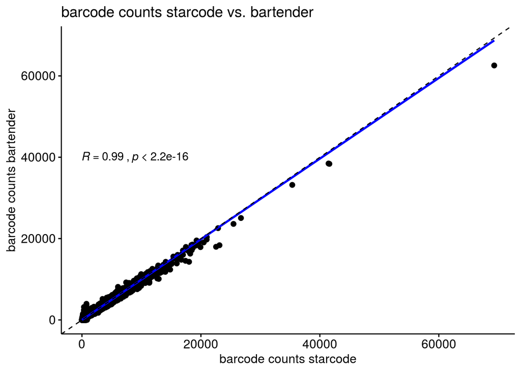

# Conlusion barcode clustering:

- optimal starcode settings: levenshtein distance of 1
- optimal bartender settings: hamming distance of 2
- starcode and bartender perform equally well - starcode a bit better
- next time design barcodes requiring levenshtein distance of 3

## Add barcode annotation to barcode counts & extract first bc read count information

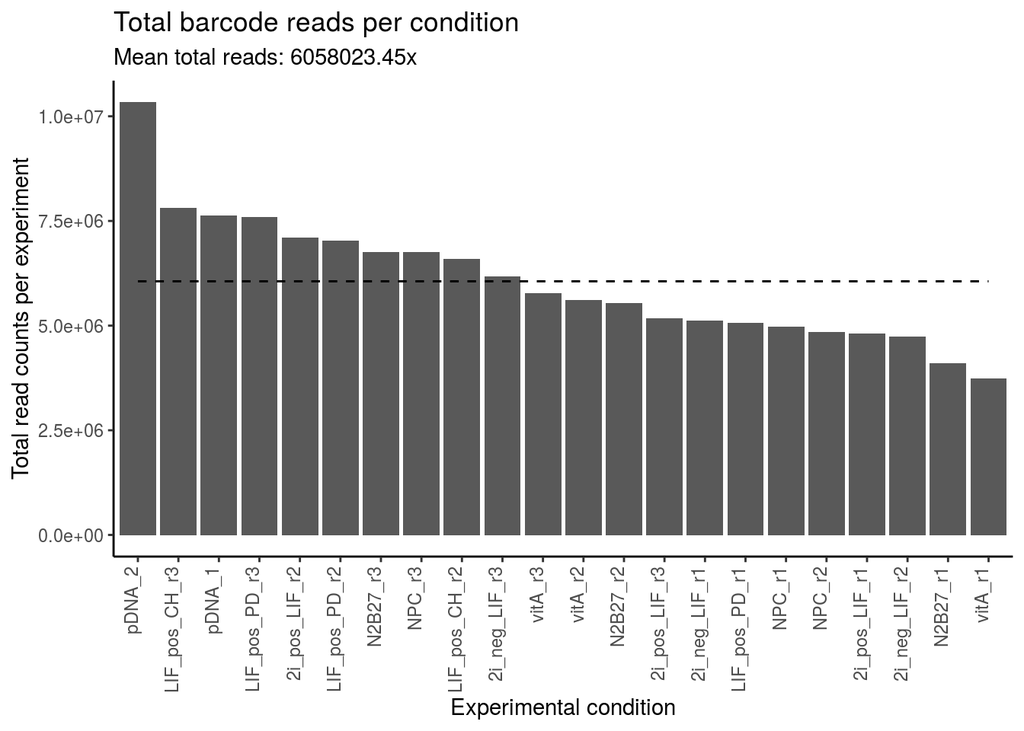

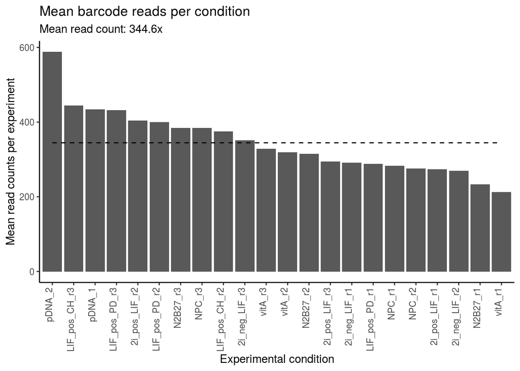

## Get a closer look at unmatched barcodes

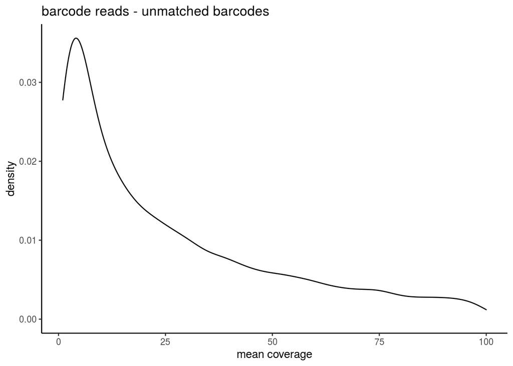

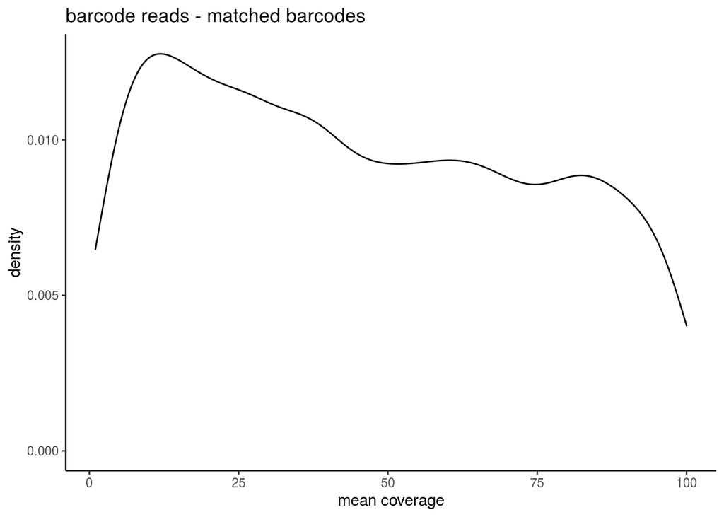

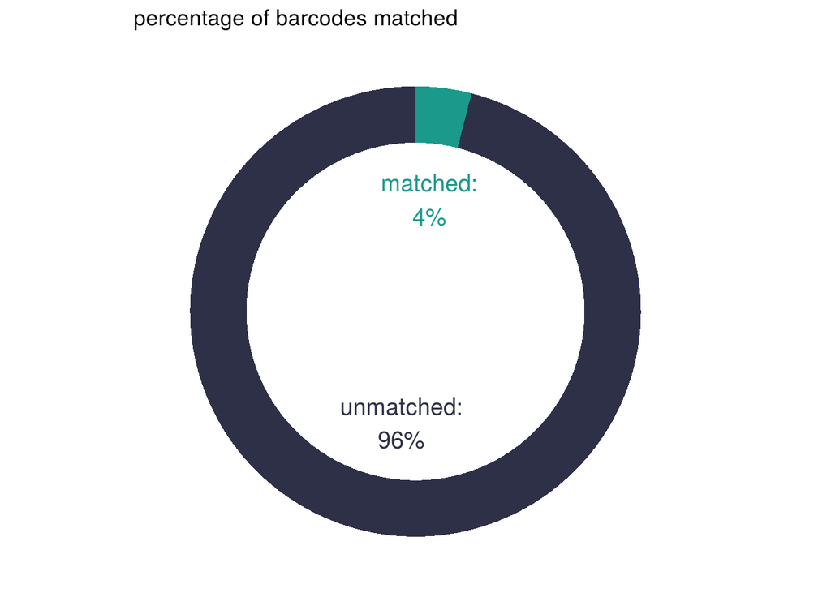

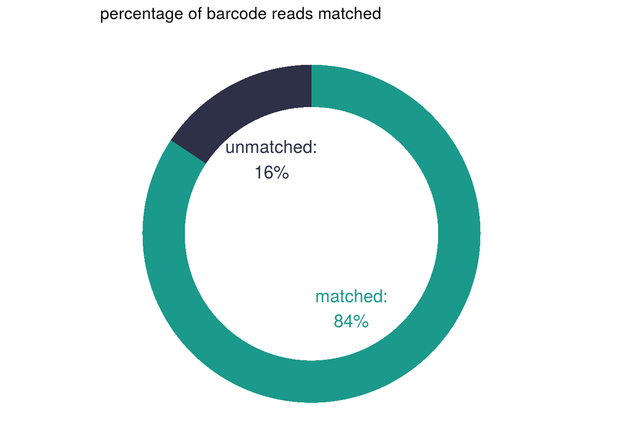

## We still have a lot of unmatched barcodes - Match unmatched barcodes to designed barcodes

### Conclusion barcode clustering:

- I manually added barcodes with high correlation and levenshtein distance of 1 to 1 barcode to get more reads

## Check again how many bc reads per experiment we have

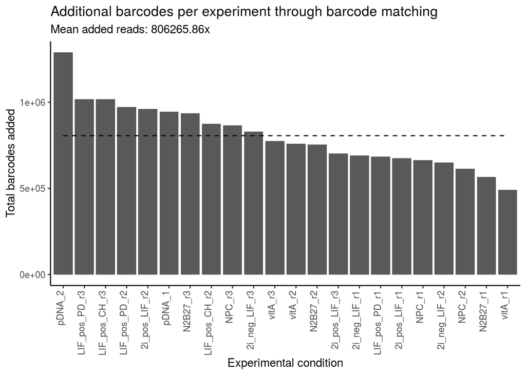

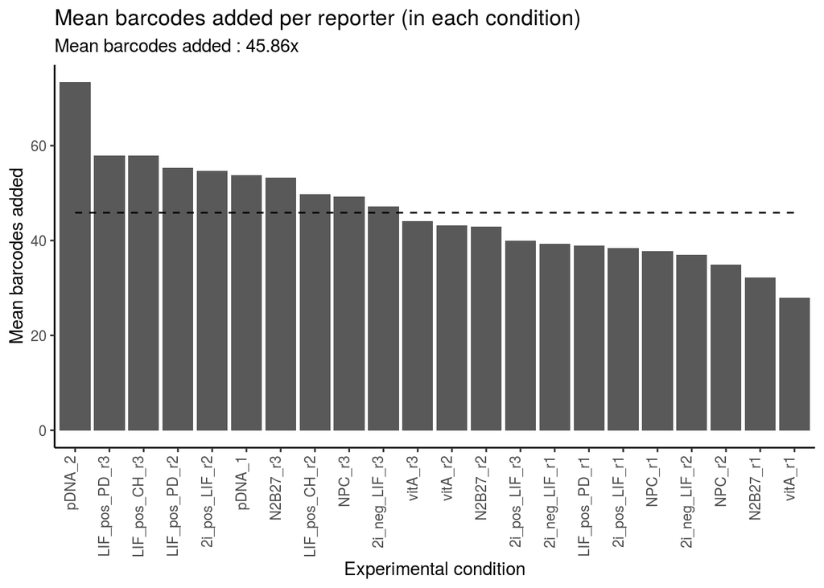

## Check again how many unmatched barcodes are left

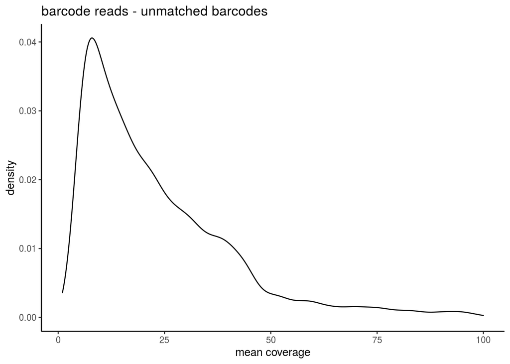

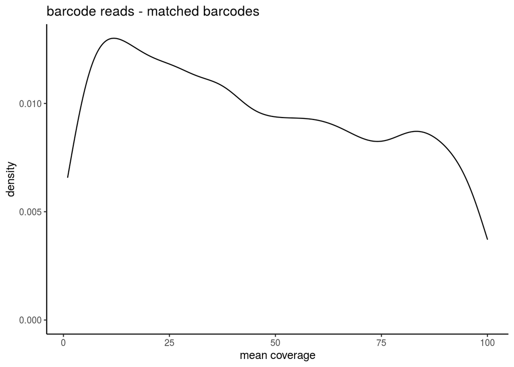

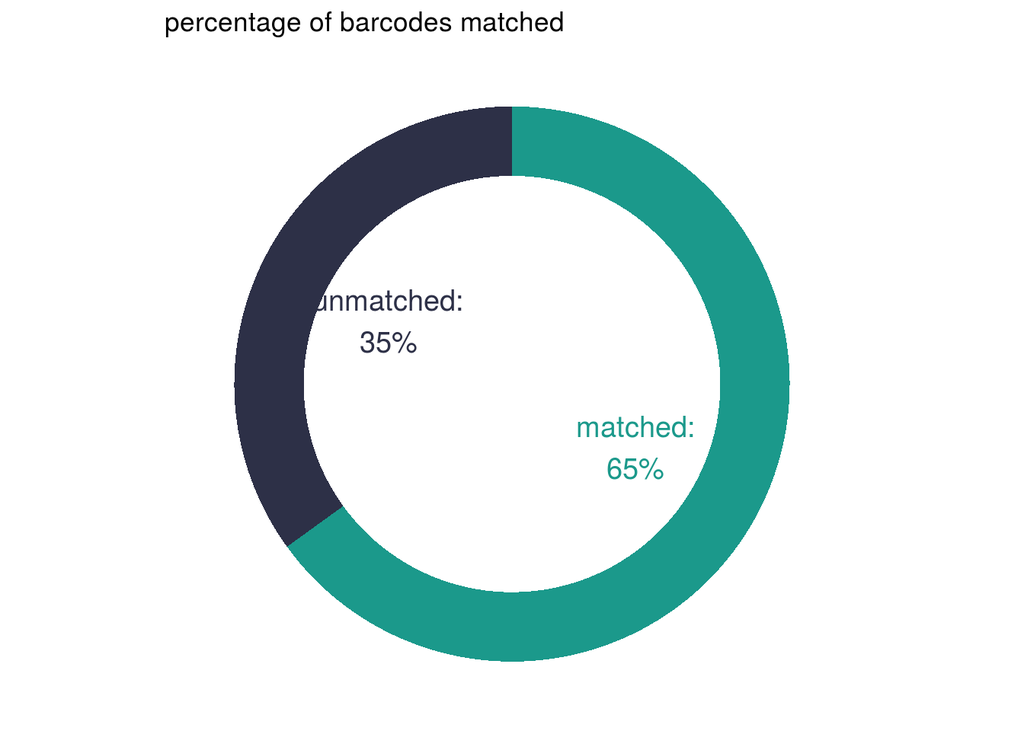

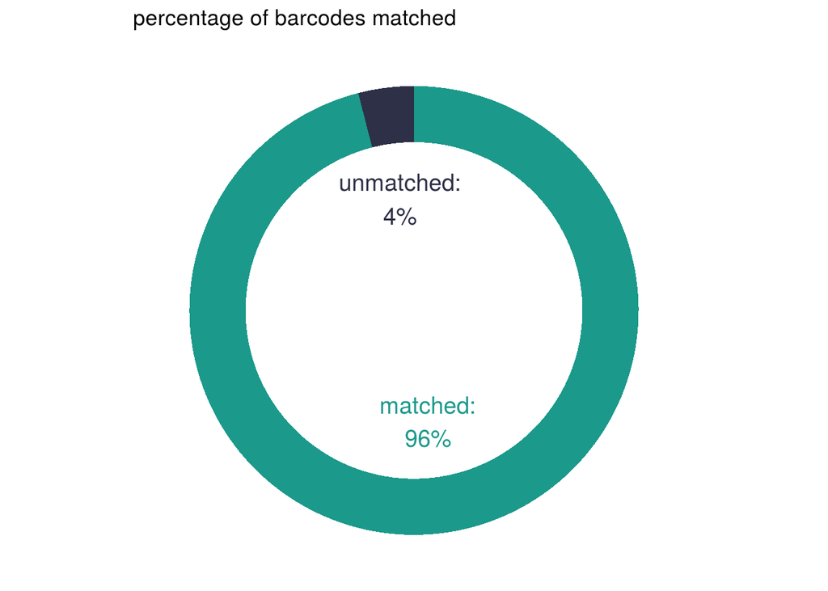

## Inspect pDNA counts to characterize the transfected library

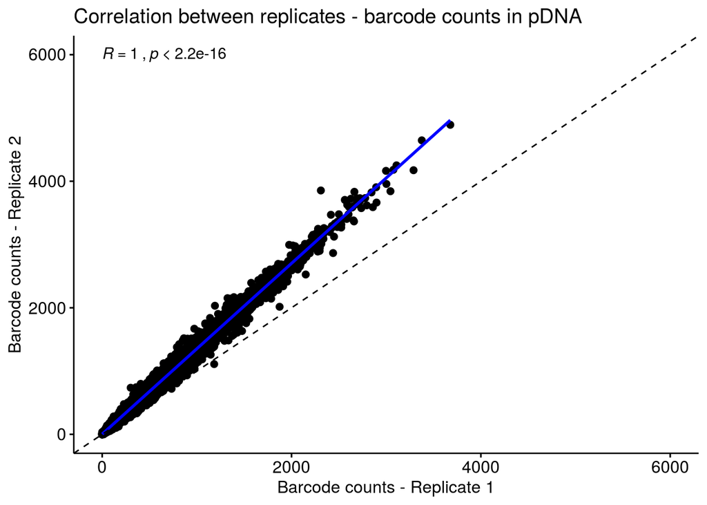

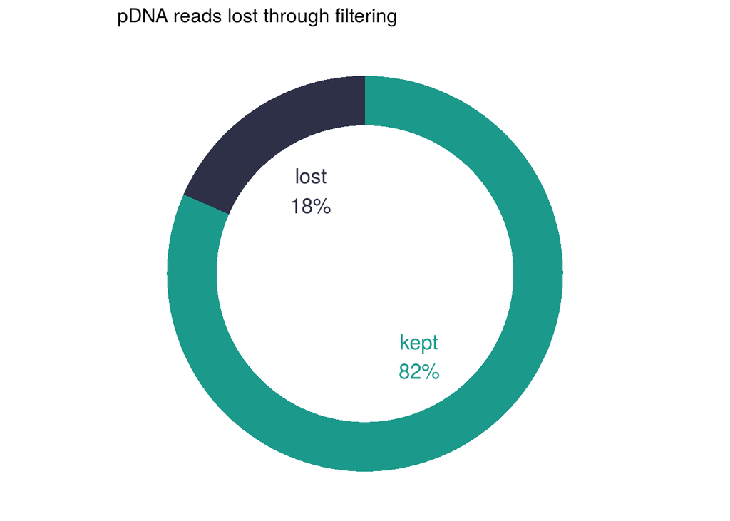

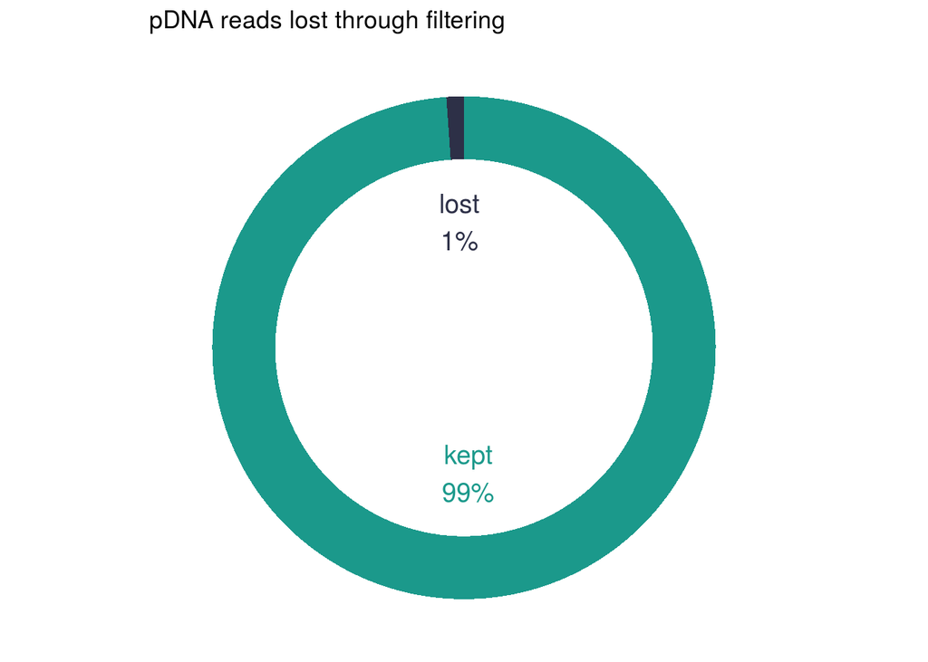

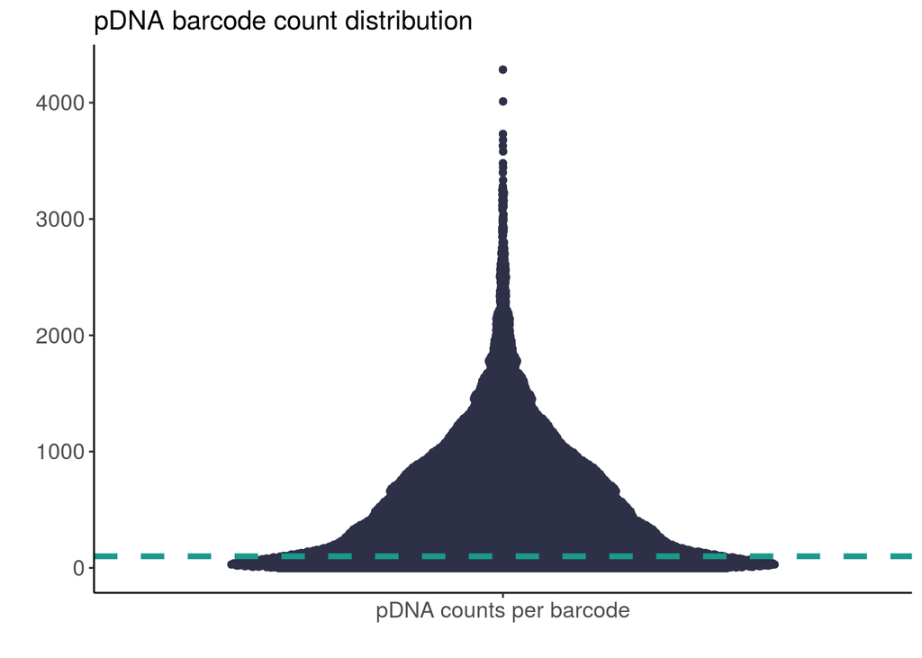

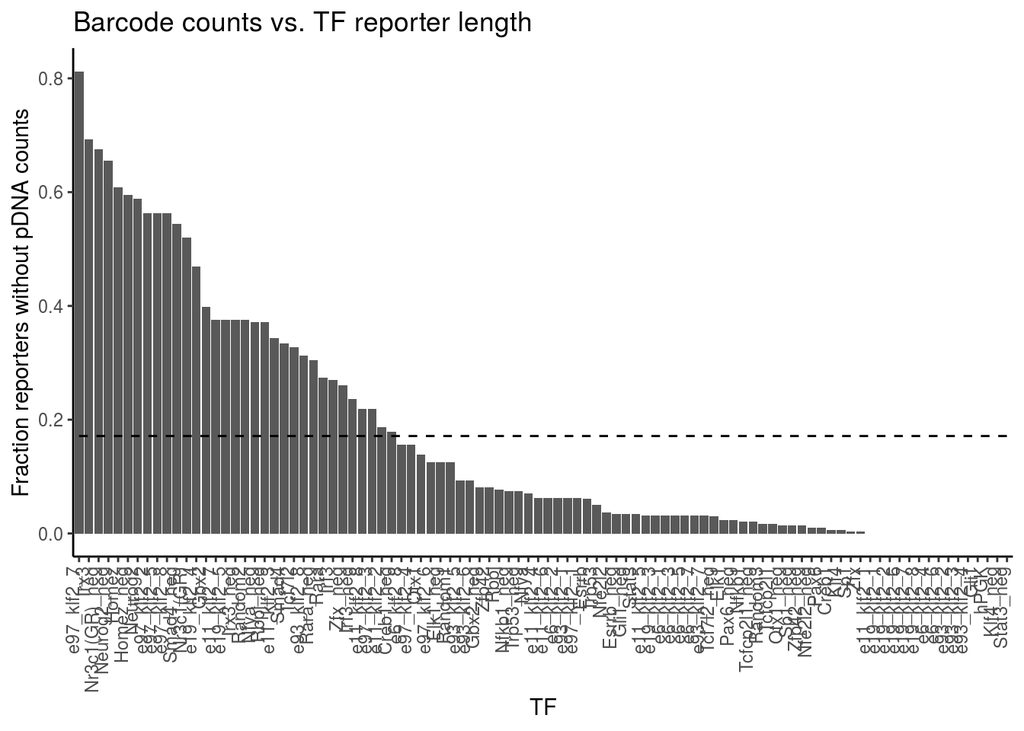

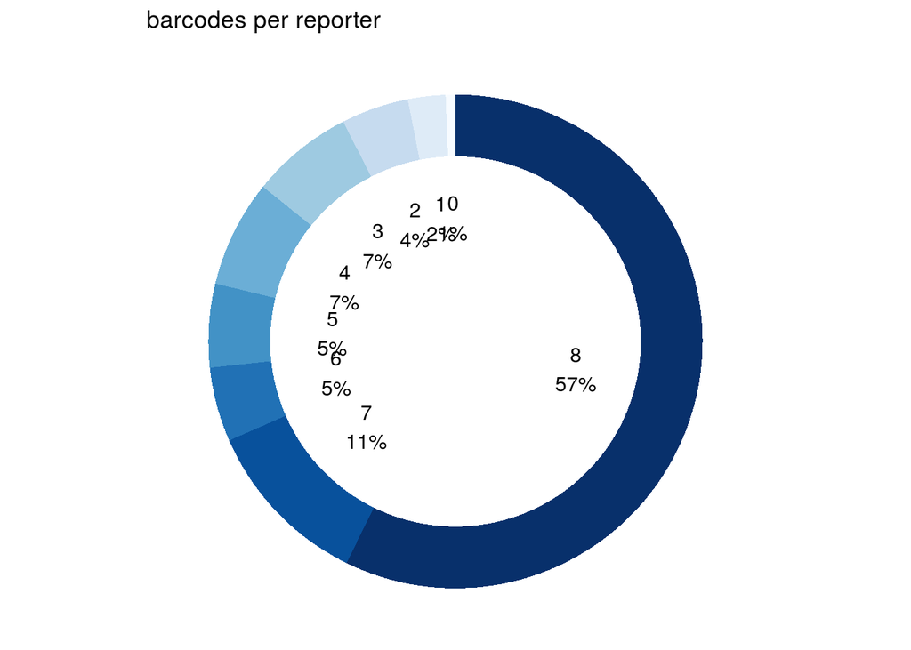

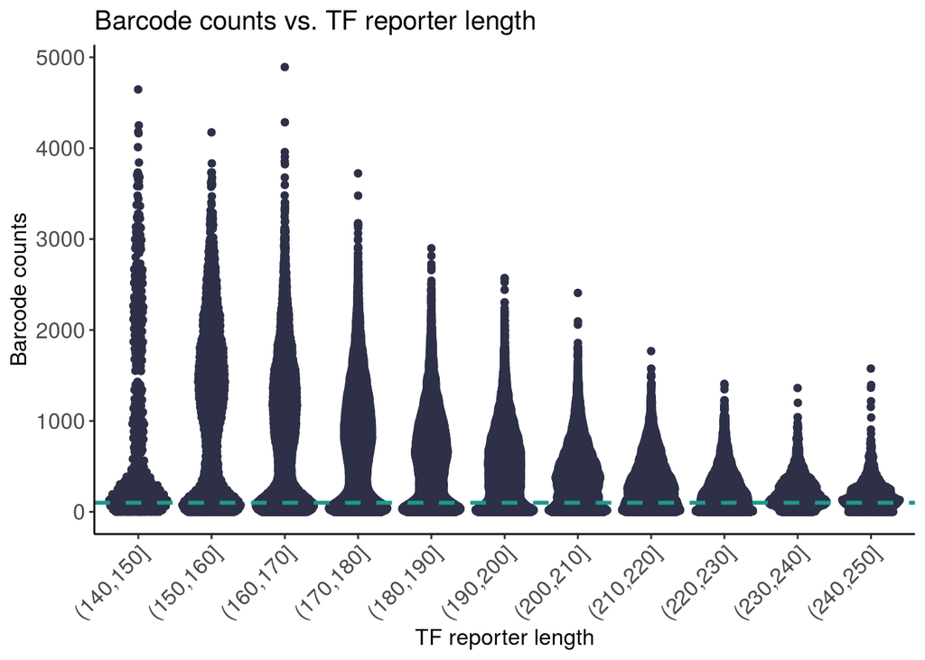

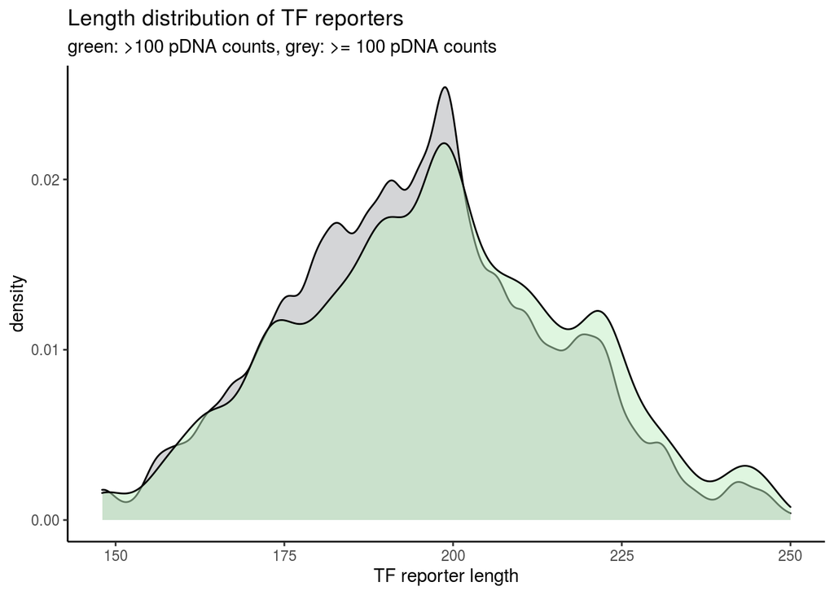

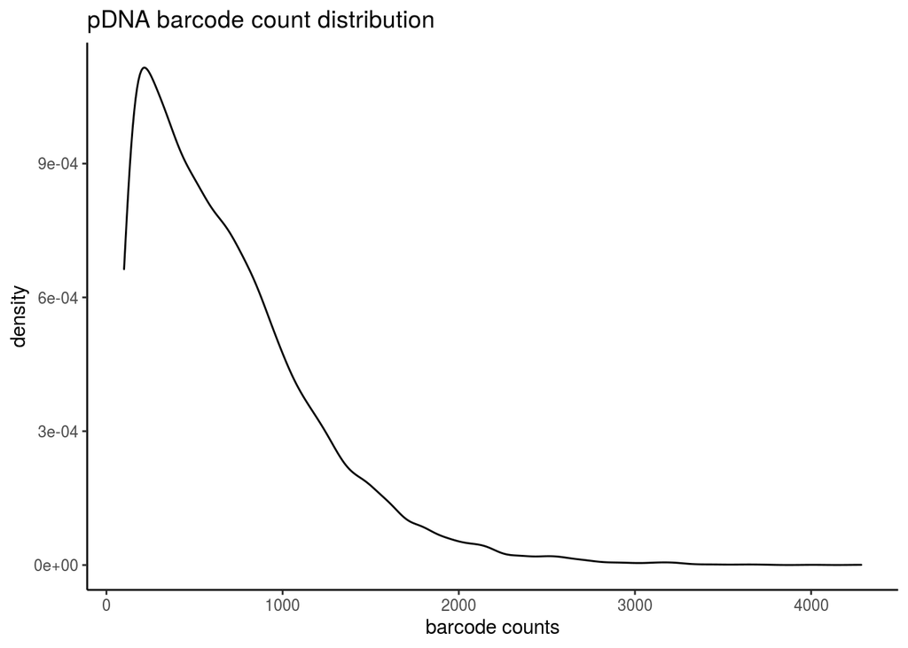

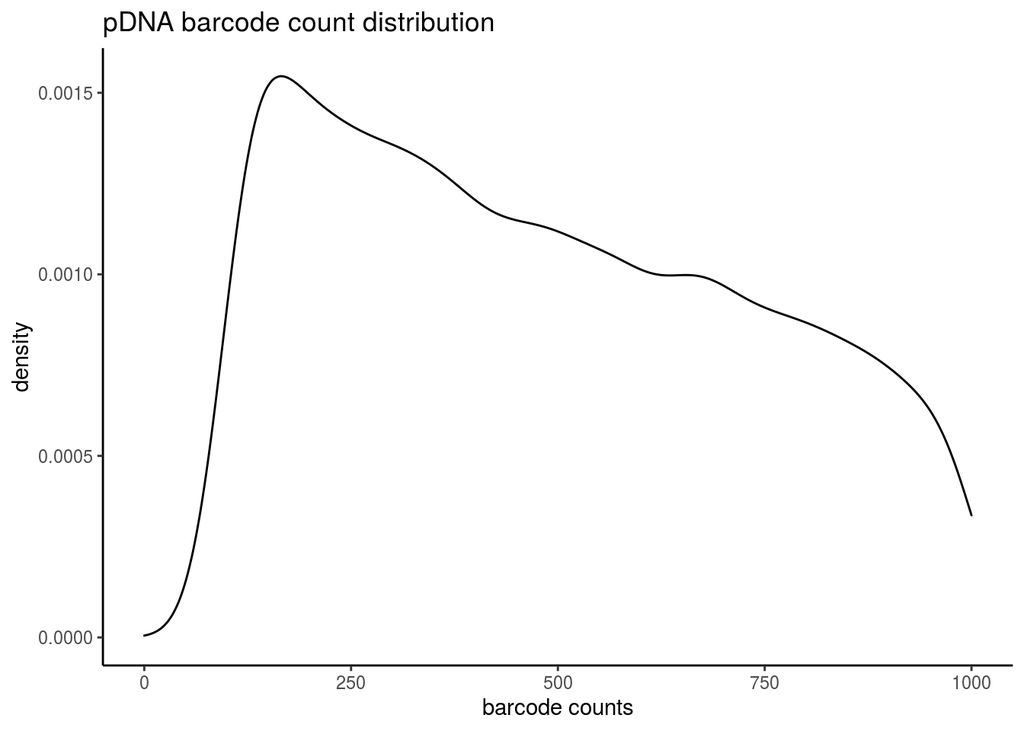

## Restructure df

## Data quality plots - total reads

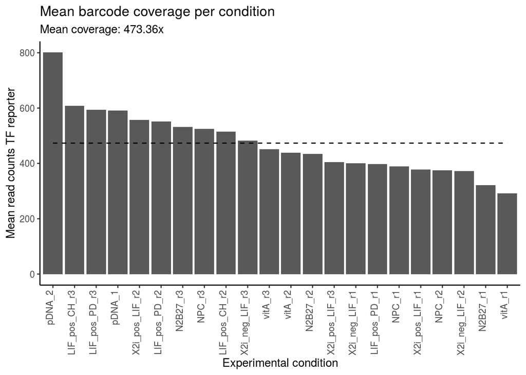

## Normalization of barcode counts in two steps:

1. Divide barcode counts through sequencing depth - I assume that sequencing depth is not skewed by differential reporter activity
2. Divide cDNA barcode counts through pDNA barcode counts to get activity

[output not shown]

[output cut: 127 more lines]

## Calculate mean activity - filter out outlier barcodes

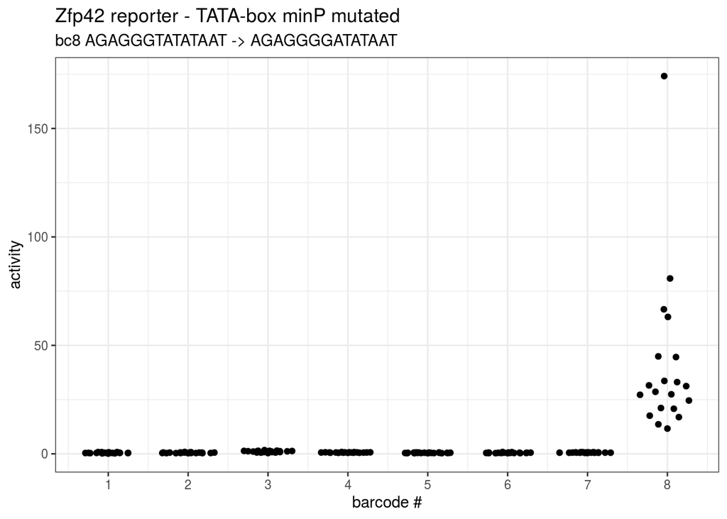

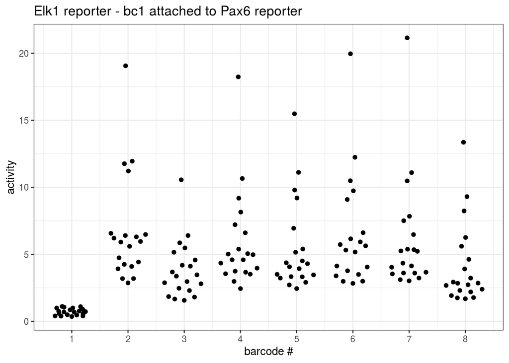

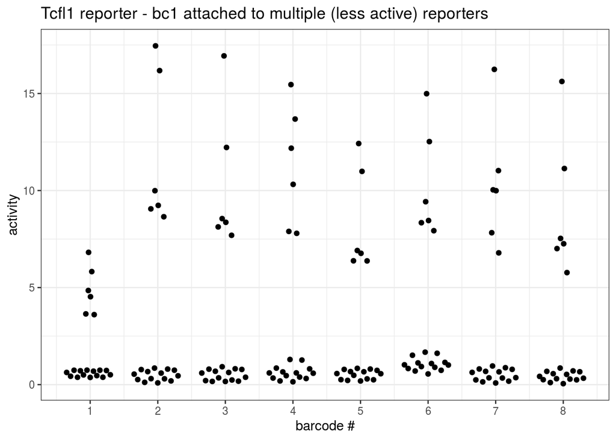

## Filter out data using pDNA-insert-seq data

## pDNA data seems ambigous - data doesn’t match sometimes - exclude for now

## Add pDNA data

```r
pDNA <- bc_df[grep("pDNA", bc_df$condition),] %>%
  select(barcode, bc_counts_rpm) %>% unique() %>%
  setnames("bc_counts_rpm", "pDNA_counts_rpm") %>%
  mutate(pDNA_counts_rpm = ave(pDNA_counts_rpm, barcode, FUN = function(x) mean(x))) %>%
  unique()
bc_df_cDNA_filt <- merge(pDNA, bc_df_cDNA_filt, all = T)
bc_df_cDNA_filt <- bc_df_cDNA_filt[!is.na(bc_df_cDNA_filt$condition),]
```

## Annotate controls

## Scale data to 1 for negative controls

```r
mean_neg_ctrl <- mean(bc_df_cDNA_filt$activity[bc_df_cDNA_filt$neg_ctrls == "Yes"])
bc_df_cDNA_filt$activity <- bc_df_cDNA_filt$activity / mean_neg_ctrl
bc_df_cDNA_filt$mean_activity <- ave(bc_df_cDNA_filt$activity, bc_df_cDNA_filt$reporter_id,
                                bc_df_cDNA_filt$condition, FUN =
                                  function(x) mean(x))
```

## Calculate correlations between technical replicates

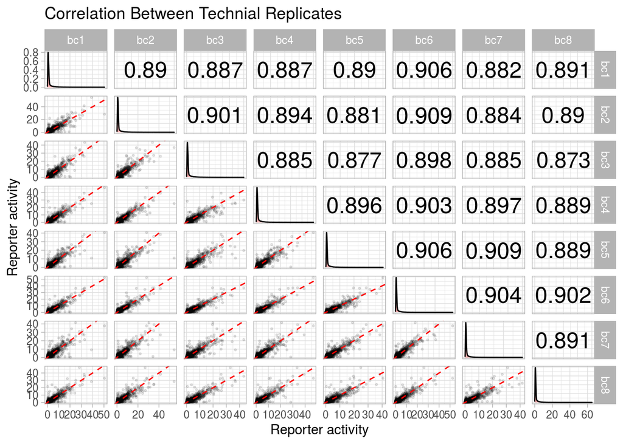

## Data quality plots - correlation between replicates

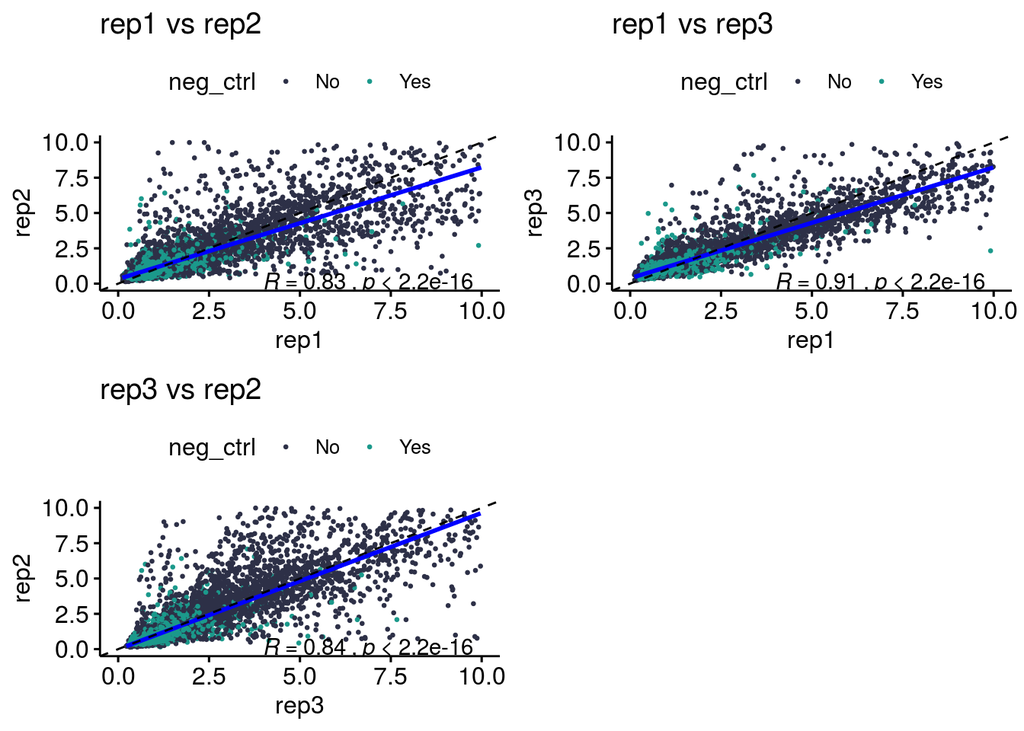

## Summarize replicates: summmarize activity values between biological replicates by their geometric mean

## Exporting data

# Session Info

```r
paste("Run time: ",format(Sys.time()-StartTime))
```

```
## [1] "Run time:  17.27065 mins"
```

```r
getwd()
```

```
## [1] "/DATA/usr/m.trauernicht/projects/tf_activity_reporter/code/SuRE_TF_1"
```

```r
date()
```

```
## [1] "Wed Jul 15 12:02:32 2020"
```